```python
import tensorflow as tf
import numpy as np
import matplotlib.pyplot as plt
import pandas as pd
```

# MNIST Dataset

## Chargement du dataset

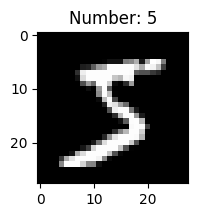

```
(60000, 10)
(10000,)
```

```python
from keras.utils import to_categorical

mnist = tf.keras.datasets.mnist
(train_images, train_labels),(test_images, test_labels) = mnist.load_data()

# Normalize and reshape images to [28,28,1]
train_images  = np.expand_dims(train_images.astype(np.float32) / 255.0, axis=3)
test_images = np.expand_dims(test_images.astype(np.float32) / 255.0, axis=3)

# View a sample image
plt.figure(dpi=100, figsize=(2,2))
plt.imshow(np.squeeze(train_images[0]), cmap='gray')
plt.title('Number: {}'.format(train_labels[0]))
plt.show()

# Passage des données en OneHotEncoding
train_labels = to_categorical(train_labels)

print(train_labels.shape)
print(test_labels.shape)
```

```python
batch_size = 128
dataset = tf.data.Dataset.from_tensor_slices((train_images, train_labels))
iterator = dataset.repeat().batch(batch_size).make_initializable_iterator()
data_batch = iterator.get_next()
```

# ConvNet

[figure not shown]

```python
n_classes = 10

weights = {
    # Convolution Layers
    'c1': tf.get_variable('W1', shape=(3,3,1,16), initializer=tf.contrib.layers.xavier_initializer()),
    'c2': tf.get_variable('W2', shape=(3,3,16,16), initializer=tf.contrib.layers.xavier_initializer()),
    'c3': tf.get_variable('W3', shape=(3,3,16,32), initializer=tf.contrib.layers.xavier_initializer()),
    'c4': tf.get_variable('W4', shape=(3,3,32,32), initializer=tf.contrib.layers.xavier_initializer()),

    # Dense Layers
    'd1': tf.get_variable('W5', shape=(7*7*32,128), initializer=tf.contrib.layers.xavier_initializer()),
    'out': tf.get_variable('W6', shape=(128,n_classes), initializer=tf.contrib.layers.xavier_initializer()),
}

biases = {
    # Convolution Layers
    'c1': tf.get_variable('B1', shape=(16), initializer=tf.zeros_initializer()),
    'c2': tf.get_variable('B2', shape=(16), initializer=tf.zeros_initializer()),
    'c3': tf.get_variable('B3', shape=(32), initializer=tf.zeros_initializer()),
    'c4': tf.get_variable('B4', shape=(32), initializer=tf.zeros_initializer()),

    # Dense Layers
    'd1': tf.get_variable('B5', shape=(128), initializer=tf.zeros_initializer()),
    'out': tf.get_variable('B6', shape=(n_classes), initializer=tf.zeros_initializer()),
}
```

On utilise la fonction **tf.nn.conv2d** pour créer des couches qui effectuent les convolutions. Cette fonction prend en entrée le tenseur x et les poids W à appliquer, et utilise la fonction d'activation reLu.

```python
# Couche de convolution 2D
def conv2d(x, W, b, strides=1):
    x = tf.nn.conv2d(x, W, strides=[1,1,1,1], padding='SAME')
    x = tf.nn.bias_add(x, b)
    return tf.nn.relu(x)
```

On définit une fonction globale pour le modèle conv net :

- Elle prend en argument le dataframe, les poids, les biais.
- Les poids et biais seront utilisés dans les différentes couches.
- Stride est le pas de décalage de la fenêtre de convolution.

En utilisant une fenetre de 2x2 (ksize=[1,2,2,1]) et un stride de 2 (strides=[1,2,2,1]), les dimensions vont être réduites de moitié. Cela aide à réduire la taille du modèle en conservant les composantes les plus importantes.

Après la dernière convolution, les données sont **reshapées** avant de passer dans la couche fully-connected.

On ajoute du **drop out**, uniquement pour l'entrainement du modèle. Drop Out : On désactive aléatoirement certain neurones, afin d'intruire une composante aléatoire dans notre réseau.

Evolution des dimensions de données :

- En entrée, nos images sont au format 28x28.
- Les deux couches de max pooling réduisent chacune de moitié les dimensions. Les couches orange foncé sur le graphique. On a donc (28 / 2) /2 = 7.

```python
def conv_net(data, weights, biases, training=False):
    # Convolution layers
    conv1 = conv2d(data, weights['c1'], biases['c1']) # [28,28,16]
    conv2 = conv2d(conv1, weights['c2'], biases['c2']) # [28,28,16]
    pool1 = tf.nn.max_pool(conv2, ksize=[1,2,2,1], strides=[1,2,2,1], padding='SAME')
    # [14,14,16]

    conv3 = conv2d(pool1, weights['c3'], biases['c3']) # [14,14,32]
    conv4 = conv2d(conv3, weights['c4'], biases['c4']) # [14,14,32]
    pool2 = tf.nn.max_pool(conv4, ksize=[1,2,2,1], strides=[1,2,2,1], padding='SAME')
    # [7,7,32]

    # Flatten
    flat = tf.reshape(pool2, [-1, weights['d1'].get_shape().as_list()[0]])
    # [7*7*32] = [1568]

    # Fully connected layer
    fc1 = tf.add(tf.matmul(flat, weights['d1']), biases['d1']) # [128]
    fc1 = tf.nn.relu(fc1) # [128]

    # Dropout
    if training:
        fc1 = tf.nn.dropout(fc1, rate=0.2)

    # Output
    out = tf.add(tf.matmul(fc1, weights['out']), biases['out']) # [10]
    return out
```

# Construction du ConvNet graph

```python
Xtrain = tf.placeholder(tf.float32, shape=(None, 28, 28, 1))
logits = conv_net(Xtrain, weights, biases)

# Loss
ytrain = tf.placeholder(tf.float32, shape=(None, n_classes))
loss = tf.reduce_mean(tf.nn.softmax_cross_entropy_with_logits_v2(logits=logits, labels=ytrain))

# Optimizer
optimizer = tf.train.AdamOptimizer(1e-4)
train_op = optimizer.minimize(loss)
```

## Entrainement

```python
# Accuracy
test_predictions = tf.nn.softmax(conv_net(test_images, weights, biases))
acc,acc_op = tf.metrics.accuracy(predictions=tf.argmax(test_predictions,1), labels=test_labels)

# Passer les images
batch_images, batch_labels = sess.run(data_batch)
feed_dict = {Xtrain: batch_images, ytrain: batch_labels}
sess.run(train_op, feed_dict=feed_dict)
```

## Entrainement avec les placeholders

```python
from tqdm import tqdm # Barre de progression
nepochs = 5

sess = tf.Session()
sess.run(tf.global_variables_initializer())
sess.run(tf.local_variables_initializer())
sess.run(iterator.initializer)

for epoch in range(nepochs):
    for step in tqdm(range(int(len(train_images)/batch_size))):

        # Batched data
        batch_images, batch_labels = sess.run(data_batch)

        # Train model
        feed_dict = {Xtrain: batch_images, ytrain: batch_labels}
        sess.run(train_op, feed_dict=feed_dict)

    # Test model
    accuracy = sess.run(acc_op)

    print('\nEpoch {} Accuracy: {}'.format(epoch+1, accuracy))
```

```
Epoch 1 Accuracy: 0.9359999895095825
```

```
Epoch 2 Accuracy: 0.9484500288963318
```

```
Epoch 3 Accuracy: 0.956333339214325
```

```
Epoch 4 Accuracy: 0.9612249732017517
```

```
Epoch 5 Accuracy: 0.9646599888801575
```

## Entrainement sans les *placeholders*

```python
batch_images, batch_labels = iterator.get_next()
logits = conv_net(batch_images, weights, biases, training=True)
loss = tf.reduce_mean(tf.nn.softmax_cross_entropy_with_logits_v2(logits=logits,
                                                                 labels=batch_labels))
train_op = optimizer.minimize(loss)

sess = tf.Session()
sess.run(tf.global_variables_initializer())
sess.run(tf.local_variables_initializer())
sess.run(iterator.initializer)

for epoch in range(nepochs):

    for step in tqdm(range(int(len(train_images)/batch_size)))
        sess.run(train_op)

    accuracy = sess.run(acc_op)
    print('\nEpoch {} Accuracy: {}'.format(epoch+1, accuracy))
```

# Test predictions

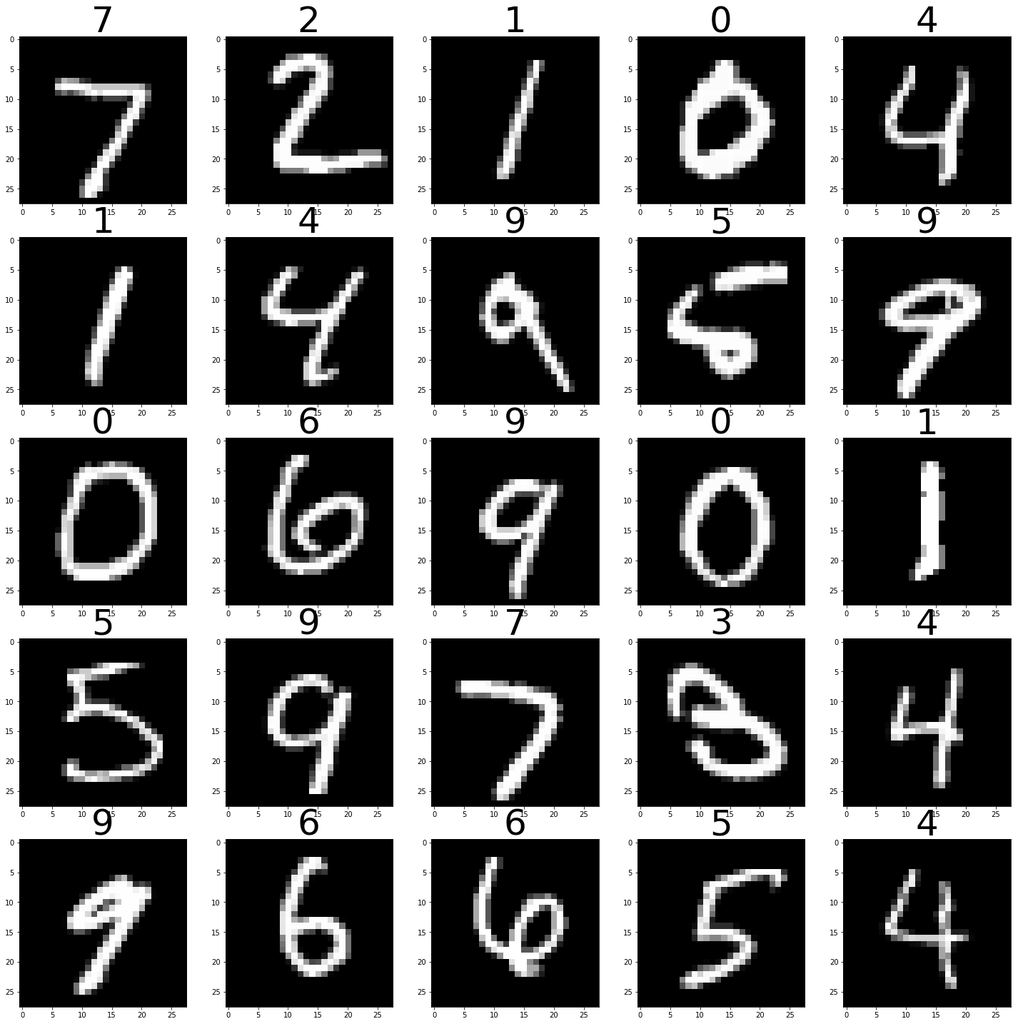

[figure not shown]

```python
onehot_predictions = sess.run(test_predictions)
predictions = np.argmax(np.squeeze(onehot_predictions), axis=1)

f, axarr = plt.subplots(5, 5, figsize=(25,25))

for idx in range(25):
    axarr[int(idx/5), idx%5].imshow(np.squeeze(test_images[idx]), cmap='gray')
    axarr[int(idx/5), idx%5].set_title(str(predictions[idx]),fontsize=50)

plt.show()
```

## Probas de prédiction

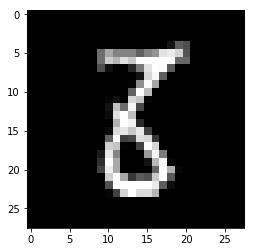

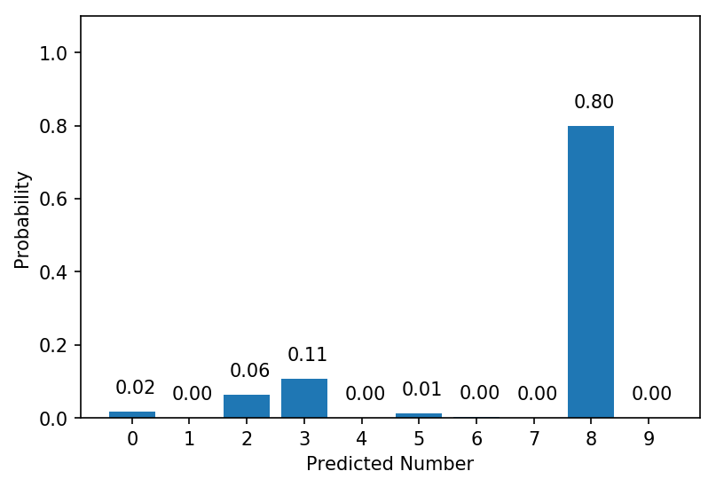

```python
idx = 3062
img = np.expand_dims(test_images[idx], 0)
plt.imshow(np.squeeze(img), cmap='gray')

# Predict value
prediction = conv_net(img, weights, biases)
probabilities = tf.nn.softmax(prediction)
probs = sess.run(probabilities)
probs = np.squeeze(probs)

# Plot probabilities
plt.figure(dpi=150)
plt.bar(range(10), probs)
for i in range(10):
    plt.text(i-0.3, probs[i]+0.05, s='{:.2f}'.format(probs[i]), size=10)
plt.ylim([0,1.1])
plt.xticks(range(10))
plt.ylabel('Probability')
plt.xlabel('Predicted Number')
plt.show()
```

# Equivalent Keras

```python
from keras.models import Sequential, Model
from keras.layers import Dense, Activation, Dropout, Flatten
from keras.layers import Conv2D, MaxPooling2D, Input
from keras.optimizers import Adam
from keras.datasets import mnist
from keras.utils import to_categorical
import numpy as np

# MNIST Dataset
(train_images, train_labels),(test_images, test_labels) = mnist.load_data()
train_images  = np.expand_dims(train_images.astype(np.float32) / 255.0, axis=3)
test_images = np.expand_dims(test_images.astype(np.float32) / 255.0, axis=3)
train_labels = to_categorical(train_labels)
test_labels = to_categorical(test_labels)

# Training parameters
batch_size = 128
n_epochs = 5
n_classes = 10

# Create the model
model = Sequential()

# Convolution Layers
model.add(Conv2D(16, 3, activation='relu', input_shape=(28, 28, 1), padding='same'))
model.add(Conv2D(16, 3, activation='relu', padding='same'))
model.add(MaxPooling2D(pool_size=2, padding='same'))
model.add(Conv2D(32, 3, activation='relu', padding='same'))
model.add(Conv2D(32, 3, activation='relu', padding='same'))
model.add(MaxPooling2D(pool_size=2, padding='same'))

# Dense Layers
model.add(Flatten())
model.add(Dense(128, activation='relu'))
model.add(Dropout(0.2))
model.add(Dense(n_classes, activation='softmax'))

# Optimizer
optimizer = Adam(lr=1e-4)

# Compile
model.compile(loss='categorical_crossentropy',
              optimizer=optimizer,
              metrics=['categorical_accuracy'])

# Train model
model.fit(train_images,
          train_labels,
          epochs=n_epochs,
          batch_size=batch_size,
          validation_data=(test_images, test_labels)
          )

# Show Sample Predictions
predictions = model.predict(test_images[:25])
predictions = np.argmax(predictions, axis=1)
f, axarr = plt.subplots(5, 5, figsize=(25,25))
for idx in range(25):
    axarr[int(idx/5), idx%5].imshow(np.squeeze(test_images[idx]), cmap='gray')
    axarr[int(idx/5), idx%5].set_title(str(predictions[idx]),fontsize=50)

# Save Model
model.save_weights("model.h5")
```

```
Train on 60000 samples, validate on 10000 samples
```

[output not shown]

# Sources

- [Understanding CNNs](https://adeshpande3.github.io/A-Beginner%27s-Guide-To-Understanding-Convolutional-Neural-Networks-Part-2/)
- [TowardsDataScience MNIST Tensorflow](https://towardsdatascience.com/guide-to-coding-a-custom-convolutional-neural-network-in-tensorflow-bec694e36ad3)